# Lyu 2018: allocation, scenario performance and assumption stress tests

2026-11-12

# 1 What this exploration measures

We take the **current coded design as the fixed BaSyc benchmark**. This report explores the saved `data/table3.rds`: 10000 trials in each of six scenarios, 60000 trials total. It does not compare runs or try to match the paper’s numerical results. The copula section is a proposal only.

The saved run uses **strict n > 3** for intratrial safety and starts global termination and exclusion after the first cohort completes its sequence. Equal PAVA weights, higher-position nearest-target ties and the existing restricted-revote fallback are retained. These recorded settings define this benchmark throughout the exploration.

Settings recorded in the input RDS

| setting | value |
| --- | --- |
| nsim_per_scenario | 10000 |
| maximum_patients | 15 |
| cohort_size | 3 |
| cycles | 3 |
| target | 0.3 |
| EI | (0.25,0.35) |
| safety_min_n | 4 |
| mts_screen_min_n | 0 |
| global_monitor | after_first_sequence |
| pava_weights | equal |
| nearest_tie | higher |
| no_mts_fallback | restricted_revote |
| outcome_generator | independent patient/cycle Bernoulli |
| seed | 2018 |

Use three distinct questions to judge performance:

1. **Recommendation:** does the design choose the true MTS, another safe path, an unsafe path, or no path?
2. **Exploration:** does a patient ever complete the true MTS, so it can enter the final sequence-specific analysis?
3. **Patient allocation:** how much treatment is delivered in truly unsafe dose/cycle cells, and how many patients reach later cycles?

Here, a truly safe sequence has every cycle probability **below 0.35**, the simulation’s truth convention. This differs from the posterior safety event used by the design, which compares an unknown cell probability with 0.30. Exact-MTS selection is a stricter metric than selecting any safe sequence. For S4 there is no safe sequence: **no recommendation is the correct decision**. With 10,000 trials, the Monte Carlo standard error of an unconditional probability is at most 0.5 percentage points. Conditional selection uses only trials observing the true path and has a smaller effective denominator.

| Scenario | True MTS | Correct decision (%) | Safe rec. (%) | Unsafe rec. (%) | No MTS (%) | Early stop (%) |
| --- | --- | --- | --- | --- | --- | --- |
| S1 | 221 | 20.70 | 60.98 | 34.97 | 4.05 | 3.98 |
| S2 | 222 | 14.51 | 69.35 | 26.60 | 4.05 | 3.99 |
| S3 | 333 | 19.52 | 99.73 | 0.00 | 0.27 | 0.27 |
| S4 | None | 97.24 | 0.00 | 2.76 | 97.24 | 96.30 |
| S5 | 222 | 37.14 | 67.57 | 32.18 | 0.25 | 0.25 |
| S6 | 111 | 45.21 | 45.21 | 51.10 | 3.69 | 3.61 |

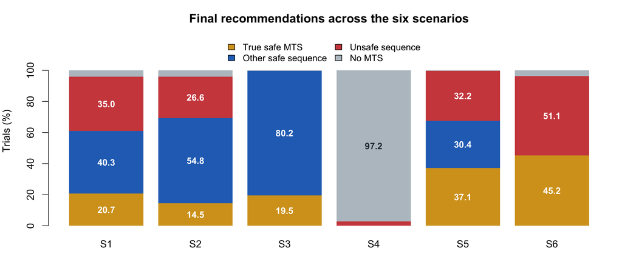

Final recommendation categories, across all saved trials. In S4, the gray no-MTS category is the correct decision; the gold category refers only to a true safe MTS.

# 2 Why the true scenarios differ

For a fixed three-cycle sequence, the truth criterion is

$$q_s=\frac{p_{s_1,1}+p_{s_2,2}+p_{s_3,3}}{3},
\qquad \max_j p_{s_j,j}<0.35.$$

The following plot shows all ten nonincreasing sequences. A TPC near 0.30 does not make a sequence safe when one cycle is overly toxic. Gold marks the true MTS; red marks a sequence containing an unsafe cycle. The shaded region is the EI, (0.25, 0.35).

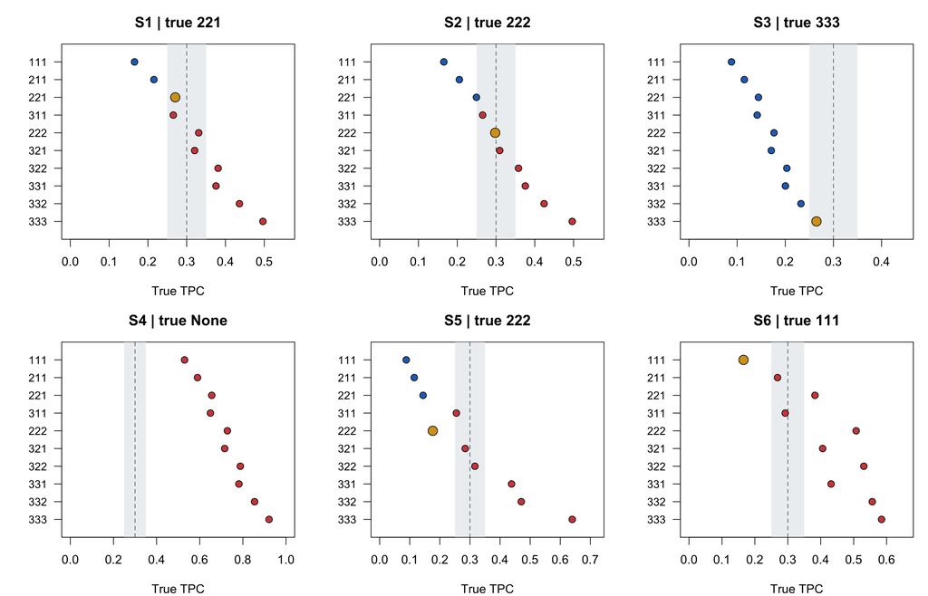

True sequence TPC and cellwise safety. Blue and gold points are safe; red points contain an unsafe cycle. Gold identifies the true MTS. S5 and S6 use the highest safe sequence below target because no safe sequence reaches the EI.

S1 and S2 have different cycle-specific safety frontiers despite similar first-cycle probabilities. In S1, D2/C3 has probability 0.363 and is unsafe; the true MTS is 221, with TPC 0.2705. In S2, D2/C3 is safe at 0.3267, making 222 the true MTS with TPC 0.2979. Its neighboring 221 has TPC **0.2495**, just below the lower EI boundary. Small changes in the toxicity surface therefore change which complete path the design must explore and recognize.

# 3 Allocation and exposure

These plots use **all evaluated dose/cycle observations**, including those from patients who did not finish three cycles and trials that stopped early. They do not restrict allocation to patients completing nonincreasing paths.

## 3.1 How much treatment reaches each cycle?

Each bar represents the 15 planned patients in a trial. The gray portion is the mean number without an evaluable observation in that cycle, combining non-enrollment and failure to reach/complete that assessment. Thus later-cycle bars retain the loss of follow-up rather than renormalizing the survivors to 100%.

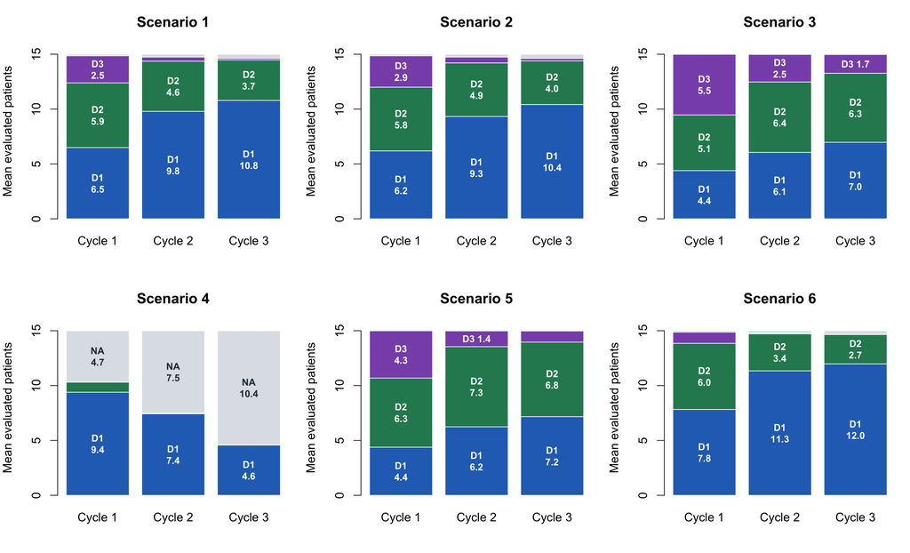

Mean evaluated patients per dose and cycle, per trial. Blue D1, green D2, purple D3; gray NA means no evaluated observation out of 15 planned patients. Numbers within sufficiently large segments identify dose and mean patient count.

## 3.2 Which dose/cycle cells receive patients?

The heatmaps combine mean allocation with true toxicity. A red border marks a truly unsafe cell; a gold inner border marks a cycle component of the true MTS. Color intensity represents allocation on the same 0-to-15 scale in every panel.

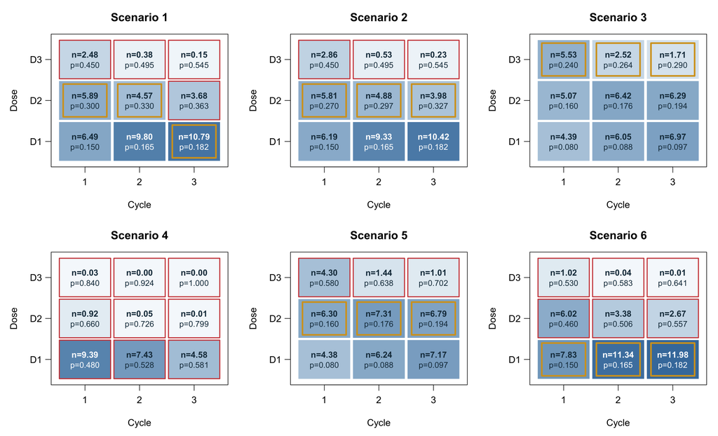

Allocation heatmaps. Each cell gives mean evaluated patients n and true DLT probability p. Darker blue means more allocation; red borders mean p >= 0.35; gold borders locate the true MTS.

Define unsafe evaluated exposure using the truth, not the posterior decision:

$$\text{Unsafe exposure}
=\frac{\sum_{b,d,j}n_{bdj}\,\mathbf1\{p_{dj}\ge0.35\}}
{\sum_{b,d,j}n_{bdj}}.$$

This is a patient-cycle proportion, not the percentage of distinct patients ever receiving an unsafe dose. Multiple DLTs in one patient also contribute multiple events to the mean DLT count.

| Scenario | Mean enrolled | Mean completed | Mean evaluated cycles | Mean DLTs | Unsafe exposure (%) |
| --- | --- | --- | --- | --- | --- |
| S1 | 14.86 | 14.62 | 44.23 | 10.56 | 15.12 |
| S2 | 14.86 | 14.62 | 44.22 | 10.30 | 8.18 |
| S3 | 14.99 | 14.98 | 44.95 | 7.24 | 0.00 |
| S4 | 10.34 | 4.59 | 22.41 | 11.77 | 100.00 |
| S5 | 14.99 | 14.98 | 44.95 | 9.34 | 15.02 |
| S6 | 14.87 | 14.66 | 44.30 | 11.74 | 29.68 |

## 3.3 How do doses move within patients?

The following diagram uses completed patient paths. Arrow width is proportional to the mean number of patients following that transition per trial; red arrows escalate, blue arrows de-escalate, and gray arrows stay. Node labels give the mean number of completing patients at that dose/cycle. This describes **completers only**; the preceding allocation plots include all evaluated observations and should be used to assess exposure.

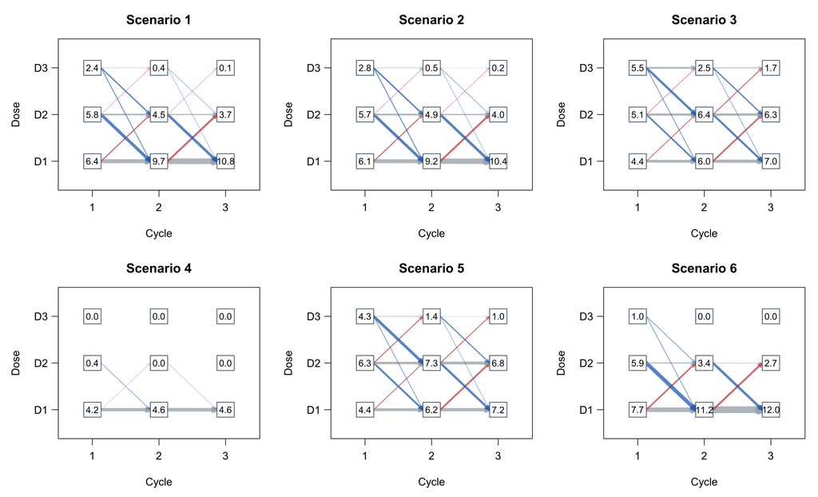

Dose transitions among patients completing all three cycles. Nodes show mean completers per trial; widths show mean transition counts. Red means escalation, blue de-escalation and gray no change. Increasing paths are allowed during exploration even though the final recommendation is nonincreasing.

# 4 Exploration versus final selection

Let V be the event that at least one patient completes the true MTS. Because final selection is restricted to observed completed sequences,

$$\Pr(\widehat s=s^*)
=\Pr(V)\Pr(\widehat s=s^*\mid V).$$

This identity separates a **coverage bottleneck** from selection after the sequence has entered the dataset. The conditional quantity is descriptive: trials visiting a path need not be comparable with those that do not.

| Scenario | True MTS | True TPC | Seen (%) | Selected (%) | Selected given seen (%) | Mean patients on true MTS |
| --- | --- | --- | --- | --- | --- | --- |
| S1 | 221 | 0.27 | 47.81 | 20.70 | 43.30 | 1.31 |
| S2 | 222 | 0.30 | 23.47 | 14.51 | 61.82 | 0.61 |
| S3 | 333 | 0.26 | 21.72 | 19.52 | 89.87 | 0.64 |
| S5 | 222 | 0.18 | 54.01 | 37.14 | 68.77 | 1.59 |
| S6 | 111 | 0.17 | 100.00 | 45.21 | 45.21 | 5.24 |

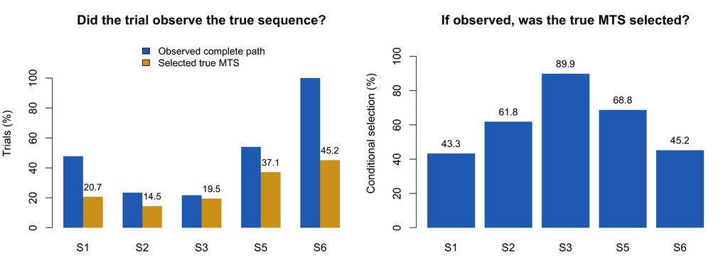

True-MTS exploration and final selection. Left: probability of observing the true path at least once and of selecting it. Right: selection conditional on observing it. S4 has no safe MTS and is omitted.

## 4.1 What each scenario teaches

- **S1: a cycle-specific boundary.** The correct path is 221, with D2 permissible in cycles 1 and 2 but unsafe in cycle 3. Coverage is 47.81%, and selection conditional on coverage is 43.30%. Both exploration and final discrimination contribute. A pooled sequence TPC can also look acceptable while containing one unsafe cell.
- **S2: a rare complete optimal path.** The true 222 is observed in only 23.47% of trials. Conditional selection is 61.82%, giving overall exact selection 14.51%. Personal de-escalation and conservative cross-cycle allocation split patients onto other paths. The low exact selection rate therefore cannot be diagnosed from final PAVA alone.
- **S3: safe exploration is too slow to reach the upper boundary.** All dose/cycle cells are safe. The true 333 is observed in only 21.72% of trials, but selected in 89.87% of trials observing it. With only five cohorts, an initial D1 cohort and conservative cross-cycle movement, this is predominantly a coverage limitation. Selecting 332 is underdosing relative to the exact oracle, not a toxicity failure.
- **S4: recognition and burden must both be measured.** There is no safe sequence. No MTS is returned in 97.24% of trials and global early termination occurs in 96.30%. The difference is no recommendation without a global early-stop flag. Nonetheless, mean exposure is 22.41 evaluated patient-cycles and 11.77 DLTs. Global monitoring begins after the first complete cohort sequence in this benchmark, so a high eventual stopping probability alone does not imply low burden.
- **S5: a large toxicity jump helps define the safe boundary.** D2 is safe, while D3 starts at 0.58. The true 222 has TPC 0.1765: no safe path reaches the EI, so the highest safe sequence below target is the oracle. Coverage is 54.01% and conditional selection is 68.77%. This gives a clearer flat boundary than S1/S2, although unsafe recommendations still occur in 32.18% of trials.
- **S6: the starting sequence is already optimal.** Only D1 is safe. The true 111 is always observed, so coverage is not the limitation. Exact and safe recommendation probabilities both equal 45.21%. Unsafe alternatives such as 211 can have a TPC near target despite an unsafe first cycle. Moreover, 29.68% of evaluated exposure is unsafe: its relatively high exact-selection probability should not obscure this burden.

These explanations combine the known truth geometry and observed allocations. They are diagnostic interpretations, not causal effects established by changing one design component at a time.

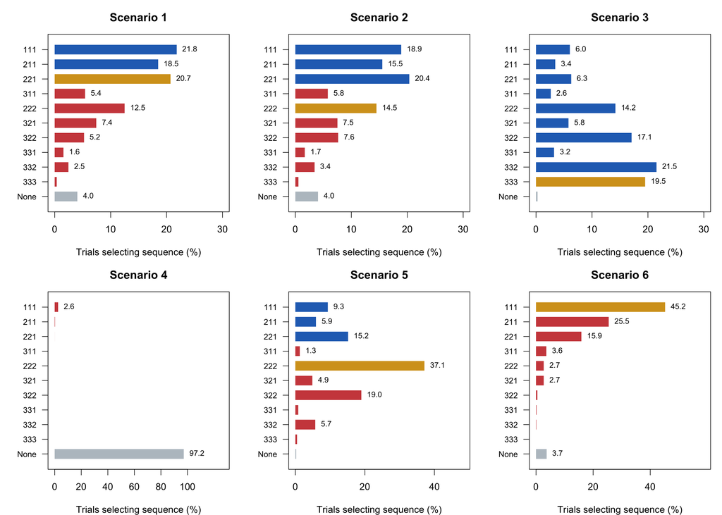

Final selection by sequence. Gold is the true safe MTS, blue other safe sequences, red unsafe sequences, gray no MTS. Axes are percentages and panel limits vary to keep small probabilities readable; S4 no MTS is correct.

# 5 Stress tests of intensity ordering and cycle trends

The copula proposal is now in copula_proposal.Rmd. Here we change the **marginal dose/cycle risks**, while retaining independent patient/cycle random numbers and the current coded trial rules. These are robustness experiments, not additional scenarios published by Lyu et al.

## 5.1 One truth formula, including the original six scenarios

For dose $d$ and cycle $j$, let $b_d$ be the first-cycle toxicity risk. Use

$$p_{dj}=\min\left\{1,\ b_d r^{j-1}c^{(j-1)(j-2)/2}\right\},
\qquad d,j=1,2,3.$$

Before capping, the three risks are simply $b_d(1,r,r^2c)$. The first cycle-to-cycle risk multiplier is $r$; the second is $rc$. Thus $c<1$ slows relative growth, and $r>1,rc<1$ produces a peak followed by recovery. Slower relative growth does not always mean a smaller absolute increase. The three $b_d$ values control the dose-response shape; changing $b_2$ between fixed endpoints changes its curvature. This simple family retains relative dose-response shape across cycles, until capping.

For every original scenario, **$r=1.10$ and $c=1$**, so the formula becomes $p_{dj}=\min\{1,b_d1.1^{j-1}\}$. The following are the exact inputs:

| Scenario | b1 | b2 | b3 | r | c |
| --- | --- | --- | --- | --- | --- |
| 1 | 0.15 | 0.30 | 0.45 | 1.1 | 1 |
| 2 | 0.15 | 0.27 | 0.45 | 1.1 | 1 |
| 3 | 0.08 | 0.16 | 0.24 | 1.1 | 1 |
| 4 | 0.48 | 0.66 | 0.84 | 1.1 | 1 |
| 5 | 0.08 | 0.16 | 0.58 | 1.1 | 1 |
| 6 | 0.15 | 0.46 | 0.53 | 1.1 | 1 |

`stress_probability()` reproduces all 54 saved original risk cells within $10^{-12}$. S4 D3/C3 would be $.84(1.1)^2=1.0164$; the same documented cap at one is retained. New scenarios do not require capping.

## 5.2 The four additional scenarios

|  | Scenario | Curve | b1 | b2 | b3 | r | c |
| --- | --- | --- | --- | --- | --- | --- | --- |
| 7 | 7 | Early dose jump | 0.2000 | 0.275 | 0.2850 | 1.10000 | 1.0 |
| 8 | 8 | Late dose jump | 0.2500 | 0.255 | 0.3300 | 1.02000 | 1.0 |
| 9 | 9 | Reversed S1 cycles | 0.1815 | 0.363 | 0.5445 | 0.90909 | 1.0 |
| 10 | 10 | Peak then recovery | 0.2000 | 0.270 | 0.4000 | 1.30000 | 0.5 |

- **S7:** the large increase is between D1 and D2. All nine risks are below .35, and toxicity increases across cycles. However, $I(222)=6<7=I(331)$, while $q(222)=.303417>q(331)=.280167$. The best safe sequence is 222.
- **S8:** the large increase is between D2 and D3. All nine cells remain safe and cycle risks increase. For example, $I(311)=5<6=I(222)$ but $q(311)=.281700>q(222)=.260134$. The best safe sequence is 331.
- **S9:** reverse the cycle columns of original S1. This is represented by $b=1.21(.15,.30,.45)$, $r=1/1.1$, and $c=1$. Reversal preserves the entire collection of intensity/TPC pairs, so intensity ordering still holds; risks now decrease across cycles. The best nonincreasing safe sequence is 111, but the best safe sequence without that restriction is 122.
- **S10:** $r=1.3,c=.5$ gives cycle multipliers $(1,1.3,.845)$: risk rises, then falls. Global intensity ordering also fails. Its reversed pairs involve unsafe sequences; ordering among truly safe sequences holds. The best nonincreasing safe sequence is 211, versus 213 unrestricted.

Here $I(s)$ sums dose-level labels, and $q(s)$ averages the three true component risks. The audit considers **all 27 sequences**, not just paths that happen to be explored. A true-safe sequence has all three risks below .35, following Table 3’s truth definition. This differs from posterior safety monitoring during a trial.

| Scenario | Dose monotone | Cycle nondecreasing | Intensity reversals | Safe-pair reversals | Max TPC reversal |
| --- | --- | --- | --- | --- | --- |
| 7 | TRUE | TRUE | 8/294 | 8/294 | 0.02325 |
| 8 | TRUE | TRUE | 3/294 | 3/294 | 0.02264 |
| 9 | TRUE | FALSE | 0/294 | 0/5 | 0.00000 |
| 10 | TRUE | FALSE | 3/294 | 0/13 | 0.01328 |

Among the 42 different-intensity pairs of nonincreasing sequences, S7 and S8 each have one reversal; S9 and S10 have none.

## 5.3 Adjust the truth curves

The controls below preview truths only. **They do not rerun simulations or change the saved results.** Start from any original or new scenario; adjust the middle first-cycle risk, initial growth, or later growth. The cycle view shows accumulation or recovery; the intensity view marks true-safe and unsafe sequences and reports actual order violations.

Starting scenario

Middle-dose cycle-1 risk

Initial growth, r

Later growth adjustment, c

## 5.4 The unchanged experiment and its truth benchmarks

The server ran **10,000 trials per new scenario**, 40,000 trials in total. Each trial uses the existing `simulate_table3()` engine: 15 patients, cohorts of three, three eight-week cycles, target .30, EI (.25,.35), and posterior cutoff .95. It retains strict $n>3$ intratrial safety, the current delayed global-monitor and exclusion timing, equal-weight PAVA, original higher-position nearest ties, final screening minimum zero, and the restricted-revote NO-MTS fallback. The delayed global rule and fallback remain documented benchmark conventions, not verified author implementations. The run checks all 18 recorded clinical and generator settings against the saved original run before saving results.

Let $\mathcal S_{\mathrm{safe}}$ contain sequences with all component risks below .35, and let $\mathcal S_{\downarrow}$ be its nonincreasing subset. We evaluate both

$$\mathcal O_{\downarrow}=\arg\min_{s\in\mathcal
S_{\downarrow}}|q(s)-.30|,
\qquad
\mathcal O_{\mathrm{all}}=\arg\min_{s\in\mathcal
S_{\mathrm{safe}}}|q(s)-.30|.$$

The first respects BaSyc’s recommendation class. The second diagnoses the cost of that restriction; it does **not** change the design’s estimand or allow increasing recommendations. Equivalent optima receive equal credit; the original single-label PCS is also retained in the data. The structural gap is the difference in their best achievable absolute target distances.

| Scenario | Best nonincreasing | Best unrestricted | Restricted distance | Unrestricted distance | Structural gap |
| --- | --- | --- | --- | --- | --- |
| 7 | 222 | 222 | 0.00342 | 0.00342 | 0.00000 |
| 8 | 331 | 331 | 0.00890 | 0.00890 | 0.00000 |
| 9 | 111 | 122 | 0.13450 | 0.02950 | 0.10500 |
| 10 | 211 | 213 | 0.06700 | 0.01067 | 0.05633 |

S9 and S10 have increasing unrestricted optima. Their unrestricted selection probability is necessarily zero under the unchanged design. This is a structural limitation, even with unlimited information, rather than a Monte Carlo error or an unsuccessful PAVA fit.

## 5.5 Saved simulation results

Total simulation and scoring runtime was **238.6 seconds** (3.98 minutes), excluding queueing, transfer and rendering. The trial engine used 236.9 seconds. Saved Slurm job: 11402780; node: u148; allocated cores: 24.

| Scenario | Trials | Best nonincreasing | Best unrestricted | Unsafe | None | Early stop | Unsafe exposure |
| --- | --- | --- | --- | --- | --- | --- | --- |
| 7 | 10000 | 7.15% | 7.15% | 0.00% | 11.56% | 11.25% | 0.00% |
| 8 | 10000 | 2.70% | 2.70% | 0.00% | 18.49% | 18.07% | 0.00% |
| 9 | 10000 | 33.22% | 0.00% | 63.13% | 3.65% | 3.65% | 17.34% |
| 10 | 10000 | 19.13% | 0.00% | 46.09% | 10.43% | 10.34% | 13.45% |

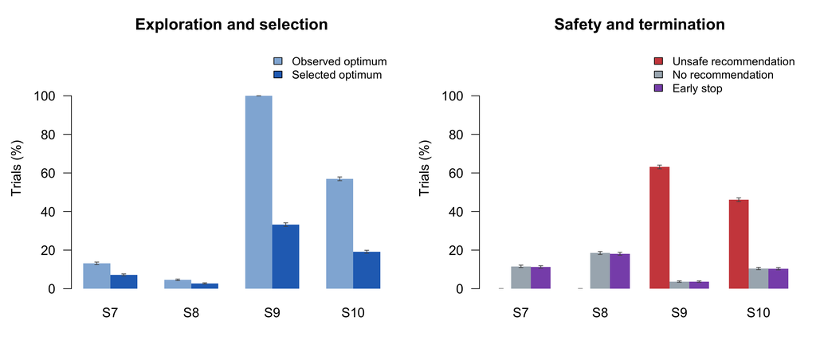

Left: probability of observing the best nonincreasing sequence and probability of selecting it. Right: unsafe recommendation, no recommendation, and early stopping. These categories on the right can overlap. Whiskers are 95% Monte Carlo intervals for trial-level binary outcomes.

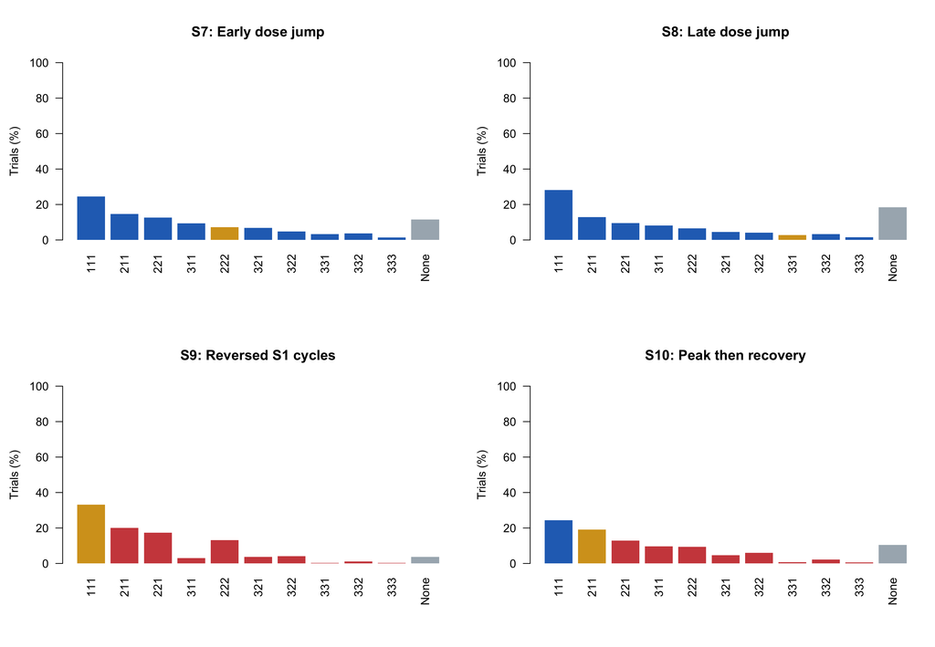

Final sequence selection. Gold: a best true-safe nonincreasing sequence; blue: another safe sequence; red: an unsafe sequence; gray: no recommendation. Labels use dose-level triples.

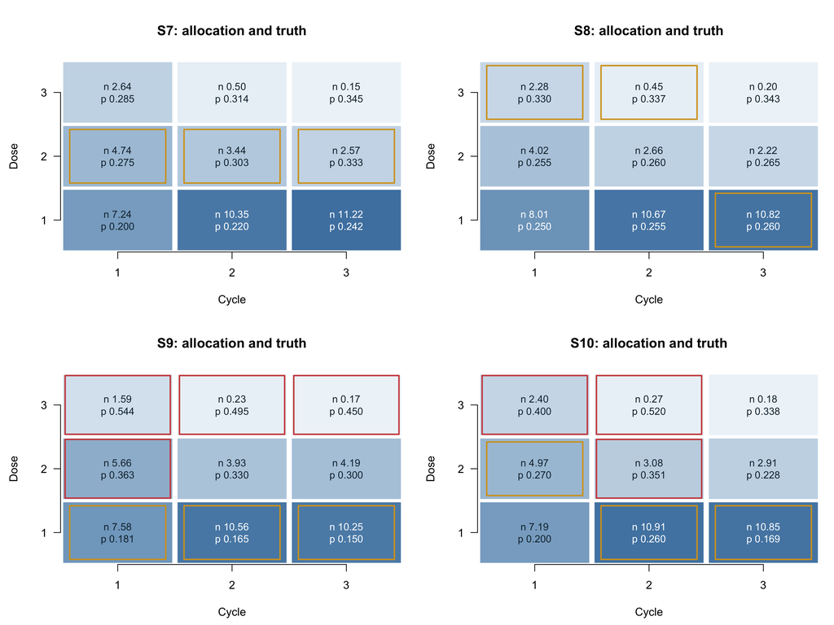

Mean evaluated patients per dose/cycle. Each cell gives mean allocation n and true risk p. Red outlines identify cells with true risk at least .35. Gold outlines mark the best true-safe nonincreasing sequence.

| Scenario | Optimum observed | Selection given observed | Fallback | Mean patients | Mean cycles | Mean DLTs |
| --- | --- | --- | --- | --- | --- | --- |
| 7 | 13.12% | 54.50% | 16.23% | 14.62 | 42.85 | 10.60 |
| 8 | 4.56% | 59.21% | 17.11% | 14.31 | 41.33 | 10.79 |
| 9 | 100.00% | 33.22% | 27.73% | 14.83 | 44.17 | 10.29 |
| 10 | 56.96% | 33.58% | 19.97% | 14.55 | 42.76 | 10.37 |

At 10,000 trials per scenario, a binary probability’s MCSE is at most 0.5 percentage points. Conditional selection uses only trials observing an optimum and has a smaller denominator. Unsafe exposure is a ratio of evaluated patient-cycles, not a trial probability. Early stopping is separated from final no recommendation and fallback use. These four scenarios change both marginal risks and exploration difficulty; performance differences alone cannot identify a causal effect of PAVA.

## 5.6 What the four results show

**S7 and S8: exploration is the main ceiling on selection.** The true optima 222 and 331 were observed in 13.12% and 4.56% of trials, respectively. Overall optimal selection was 7.15% and 2.70%; conditional on observation, it was 54.50% and 59.21%. Failure to observe the optimum therefore explains most selection failures. Both scenarios contain only true-safe cells, so zero unsafe recommendation/exposure is guaranteed by construction. Early stopping still occurred in 11.25% and 18.07% under the unchanged posterior rules.

**How often is the misspecified order exposed to data?** A reversed pair of true-safe sequences was jointly observed in only 3.54% of S7 trials and 0.75% of S8 trials. Final posterior screening may reduce these sets further. Thus these 15-patient experiments reveal a substantial exploration limitation; their low selection rates do not establish that intensity misspecification or PAVA caused the failures.

**S9: the nonincreasing recommendation restriction is structurally costly.** The design selected its best allowed safe sequence, 111, in 33.22% of trials. The unrestricted optimum, 122, cannot be recommended. Unsafe recommendations occurred in 63.13%, and 17.34% of evaluated cycles used cells with true risk at least .35. Decreasing cycle toxicity makes safe later escalation relevant, while the unchanged final class excludes it.

**S10: recovery creates a second restriction problem.** The best allowed safe sequence, 211, was selected in 19.13% of trials, while unrestricted 213 is unavailable to the final selector. Unsafe recommendation was 46.09%. D2/C2 has risk .351, only .001 above the .35 truth boundary; its classification should be read alongside the more toxic early D3 cells in the heatmap. This scenario violates global intensity order, but not order between two true-safe paths.

## 5.7 Functions called and rerunning

`stress_probability()` generates the risk matrix; `stress_sequences()` and `stress_audit()` enumerate the truth and its assumptions. `run_assumption_stress()` calls **the existing `simulate_table3()`**, which calls `run_basyc()` and `select_mts()` with the original saved settings. `summarize_assumption_stress()` summarizes saved data only. The simulator’s new optional `truth` argument changes input risks, not trial decisions. Fixed per-trial seeds preserve worker-count independence and the original six-scenario behavior. New seeds follow the same rule, using scenario IDs 7–10.

From a **local terminal** in the shared project folder:

```bash
bash unity.sh 10000 auto 2018 stress
```

This uploads changed sources, gives Unity the exact original saved benchmark, requests available Slurm cores, runs the four scenarios, downloads the single `data/assumption_stress.rds`, and renders this Rmd. The original `table3.rds` is retained. On an allocated compute node, the equivalent R command is:

```bash
Rscript --vanilla Lyu_2018/R/assumption_stress.R 10000 32 2018
```

Knitting this document never starts a simulation. The source checksums, clinical-setting comparison, scenario inputs, full trial/cell/completed-path records, runtime and Slurm metadata are stored together in the RDS.

# 6 References

- [Lyu, Curran and Ji (2018), BaSyc](https://doi.org/10.1200/PO.18.00020): trial rules and original six simulation scenarios. The additional scenarios and risk surface above are constructed stress tests.